# Homework #3 technical component

1. Plot the first principal component score on a map of the US counties. Briefly describe any spatial patterns you see.

```r
scores <- pc.svi$score
scores <- data.frame(scores)
countycomp <- cbind.data.frame(svi_raw$fips[!is.na(svi_raw$EP_POV150)], svi_raw$STATE[!is.na(svi_raw$EP_POV150)], scores[1])
names(countycomp) <- c("fips", "State", "PC1")
us <- st_read("data\\raw\\tl_2019_us_county")
us <- st_transform(us, "NAD83")
us$fips <- paste(as.character(as.numeric(us$STATEFP)), us$COUNTYFP, sep="")
us <- merge(us, countycomp, by = "fips")
table(us$STATEFP)
```

```
 01  02  04  05  06  08  10  11  12  13  15  16  17  18  19  20  21  22  23  24
 67  28  15  75  58  64   3   1  67 159   5  44 102  92  99 105 120  64  16  24
 25  26  27  28  29  30  31  32  33  34  35  36  37  38  39  40  41  42  44  45
 14  83  87  82 115  56  93  17  10  21  33  62 100  53  88  77  36  67   5  46
 46  47  48  49  50  51  53  54  55  56
 66  95 254  29  14 133  39  55  72  23
```

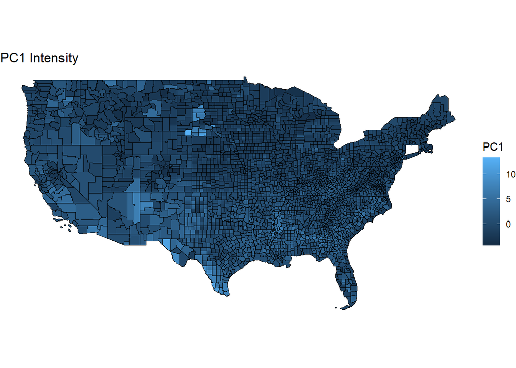

```r
us <- us[!is.na(us$State),]
us <- us[!(us$State %in% c("Alaska", "Hawaii")),]
print(ggplot(data = us) +
    geom_sf(aes(fill = PC1), color = "black") +
    labs(title = "PC1 Intensity") +
    theme_void())
```

The SVI scores seem weighted in the southwest, at least at the scale my computer can process. Also, it is worth noting that I excluded all US territories, Alaska, and Hawaii from the choropleth in order to keep images visible. Connecticut is also missing as an artifact of the source of the data.

1. Cross-validation is another method to determine the number of principal components to retain. This process requires some linear algebra that is beyond the scope of this course. As such, I have written example [code](https://github.com/gabehassler/PRGS-Intro-to-ML-2024/blob/main/examples/pca_cross_validation.jl) in Julia that demonstrates how to perform cross-validation. This procedure is a simplified versionof an approach explained in this [blog post](https://alexhwilliams.info/itsneuronalblog/2018/02/26/crossval/). For the purposes of this assignment, the `pca_cv_error` function is a black box that returns the cross-validation error for a given number of principal components. *Note: If you use a different programming language, you can use ChatGPT to translate the code to your language of choice.*

R as read by GitHub Copilot

```r
# Convert data to numeric matrix (ensure numeric columns)
X <- as.matrix(svi)
mode(X) <- "double"

# Standardize columns (mean 0, sd 1)
mu <- colMeans(X)
sd_vec <- apply(X, 2, sd)

# Avoid division by zero: if a column has sd == 0, set sd to 1 (will make standardized values 0)
sd_vec[sd_vec == 0] <- 1

X <- sweep(X, 2, mu, FUN = "-")
X <- sweep(X, 2, sd_vec, FUN = "/")

# approximates the data matrix X using the first k principal components
# X must be standardized to have mean 0 and standard deviation 1
pca_approx <- function(X, k) {
  s <- svd(X)
  U <- s$u[, seq_len(k), drop = FALSE]
  D <- diag(s$d[seq_len(k)])
  V <- s$v[, seq_len(k), drop = FALSE]
  return(U %*% D %*% t(V))
}

# computes the cross-validated error of approximating X using the first k principal components
# X must be standardized to have mean 0 and standard deviation 1
# folds is a matrix of the same size as X with integers from 1 to n_folds
# typically folds will have the numbers 1:n_folds randomly assigned for each element
pca_cv_error <- function(X, k, folds) {
  fs <- sort(unique(as.vector(folds)))
  # column means of the original X (not the standardized? matches Julia which used mean(X, dims=1) on standardized X)
  means <- colMeans(X)
  errs <- numeric(length(fs))

  for (idx in seq_along(fs)) {
    f <- fs[idx]
    X_cv <- X
    # replace entries belonging to fold f with column means
    for (col in seq_len(ncol(X_cv))) {
      rows_to_replace <- which(folds[, col] == f)
      if (length(rows_to_replace) > 0) {
        X_cv[rows_to_replace, col] <- means[col]
      }
    }

    # approximate X_cv using first k principal components
    X_hat <- pca_approx(X_cv, k)

    # compute squared error only for replaced values
    err <- 0
    for (col in seq_len(ncol(X))) {
      rows <- which(folds[, col] == f)
      if (length(rows) > 0) {
        diffs <- X_hat[rows, col] - X[rows, col]
        err <- err + sum(diffs^2)
      }
    }
    errs[idx] <- err
  }

  # return the average error normalized by total number of elements (matches Julia: sum(errs) / length(X))
  return(sum(errs) / length(X))
}

# create a matrix of random folds
set.seed(1)  # for reproducibility
n_folds <- 20
folds <- matrix(sample(seq_len(n_folds), nrow(X) * ncol(X), replace = TRUE),
                nrow = nrow(X), ncol = ncol(X))

# compute the cross-validated error of approximating X using the first k principal components for k = 1:17
k_max <- min(17, ncol(X))  # ensure we don't exceed the number of columns
cv_errors <- sapply(1:k_max, function(k) pca_cv_error(X, 17, folds))

# what is the optimal number of principal components to use?
optimal_k <- which.min(cv_errors)

cat("Cross-validated errors for k = 1:", k_max, "\n")
```

```
Cross-validated errors for k = 1: 17
```

```r
print(cv_errors)
```

```
 [1] 0.9996819 0.9996819 0.9996819 0.9996819 0.9996819 0.9996819 0.9996819
 [8] 0.9996819 0.9996819 0.9996819 0.9996819 0.9996819 0.9996819 0.9996819
[15] 0.9996819 0.9996819 0.9996819
```

```r
cat(sprintf("Optimal k (min CV error): %d\n", optimal_k))
```

```
Optimal k (min CV error): 1
```

```
a. Compute the cross-validation error for 1 to 17 principal components. If this process is parallelizable, parallelize the code. If setting a random number seed would make this work more reproducible, set a random number seed.


a. How many principal components should be retained based on the cross-validation error?
```

The provided code prints out a value of 1, but every error value comes out as 0.999681. I did have to manually adjust the k input in cv_errors, and these answers are for a value of 17, the total number of PCs involved.